# Homework 4

Dylan Maddux

2024-10-16

```r
library(Stat2Data)
library(ggplot2)
library(dplyr)
```

### Exercise 3.48

**The RailsTrails data gives information about 104 homes sold in Northampton, Massachusetts, in 2007. Use Adj2007 (the 2007 selling price in adjusted 2014 thousands of dollars) as the response variable and Distance and GarageGroup as two explanatory variables. The variable GarageGroup is a binary variable, yes or no, on whether the home has any garage spaces at all.**

**A.** Use comparative boxplots and a t-test to decide if having a garage is related to the price of a home. Summarize your results.

```r
data("RailsTrails")
t.test(Adj2007 ~ GarageGroup, RailsTrails)
```

```
##
##  Welch Two Sample t-test
##
## data:  Adj2007 by GarageGroup
## t = -2.7145, df = 94.013, p-value = 0.007896
## alternative hypothesis: true difference in means between group no and group yes is not equal to 0
## 95 percent confidence interval:
##  -93.36936 -14.48237
## sample estimates:
##  mean in group no mean in group yes
##          300.0728          353.9987
```

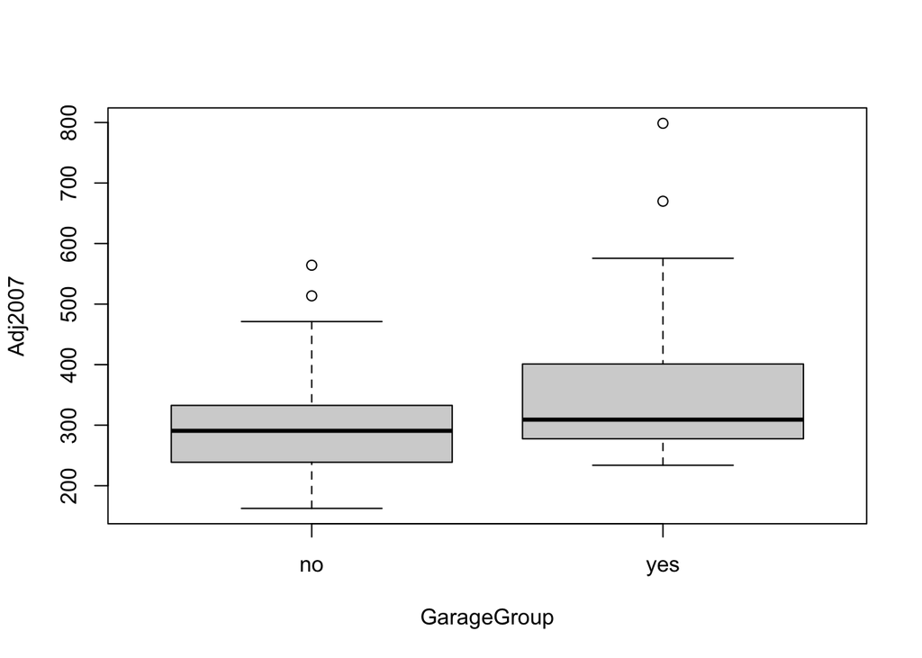

```r
plot(Adj2007 ~ GarageGroup, RailsTrails)
```

The boxplots and t-test output indicate that homes with a garage are on average significantly more expensive than homes without a garage (p = 0.007896).

**B.** Fit the simple linear regression model of Adj2007 on Distance and summarize the impact of distance to a trail on home price.

```r
rtmod1 <- lm(Adj2007 ~ Distance, RailsTrails)
summary(rtmod1)
```

```
##
## Call:
## lm(formula = Adj2007 ~ Distance, data = RailsTrails)
##
## Residuals:
##     Min      1Q  Median      3Q     Max
## -190.55  -58.19  -17.48   25.22  444.41
##
## Coefficients:
##             Estimate Std. Error t value Pr(>|t|)
## (Intercept)  388.204     14.052  27.626  < 2e-16 ***
## Distance     -54.427      9.659  -5.635 1.56e-07 ***
## ---
## Signif. codes:  0 '***' 0.001 '**' 0.01 '*' 0.05 '.' 0.1 ' ' 1
##
## Residual standard error: 92.13 on 102 degrees of freedom
## Multiple R-squared:  0.2374, Adjusted R-squared:  0.2299
## F-statistic: 31.75 on 1 and 102 DF,  p-value: 1.562e-07
```

Every 1 unit increase in distance from a trail is associated with a 54.427 decrease in home price.

**C.** Fit a model using both GarageGroup and Distance as predictors. Summarize the results.

```r
rtmod2 <- lm(Adj2007 ~ GarageGroup + Distance, RailsTrails)
summary(rtmod2)
```

```
##
## Call:
## lm(formula = Adj2007 ~ GarageGroup + Distance, data = RailsTrails)
##
## Residuals:
##     Min      1Q  Median      3Q     Max
## -167.88  -51.55  -21.88   36.79  427.49
##
## Coefficients:
##                Estimate Std. Error t value Pr(>|t|)
## (Intercept)     365.103     17.661  20.673   <2e-16 ***
## GarageGroupyes   37.892     18.032   2.101   0.0381 *
## Distance        -51.025      9.638  -5.294    7e-07 ***
## ---
## Signif. codes:  0 '***' 0.001 '**' 0.01 '*' 0.05 '.' 0.1 ' ' 1
##
## Residual standard error: 90.62 on 101 degrees of freedom
## Multiple R-squared:  0.2693, Adjusted R-squared:  0.2549
## F-statistic: 18.62 on 2 and 101 DF,  p-value: 1.311e-07
```

Holding all else constant, every 1 unit increase in distance from a trail is associated with a 51.025 decrease in home price; and houses with a garage have an average home price $37,892 higher than houses without a garage.

**D.** Fit a model with an interaction term between Distance and GarageGroup. Use the results of this model to estimate the two rates at which housing price decreases as distance increases. Is this difference in rates statistically significant?

```r
rtmod3 <- lm(Adj2007 ~ Distance*GarageGroup, data = RailsTrails)
summary(rtmod3)
```

```
##
## Call:
## lm(formula = Adj2007 ~ Distance * GarageGroup, data = RailsTrails)
##
## Residuals:
##     Min      1Q  Median      3Q     Max
## -162.46  -51.65  -17.22   30.04  425.76
##
## Coefficients:
##                         Estimate Std. Error t value Pr(>|t|)
## (Intercept)              359.083     21.295  16.862  < 2e-16 ***
## Distance                 -46.302     13.391  -3.458 0.000802 ***
## GarageGroupyes            48.862     28.108   1.738 0.085222 .
## Distance:GarageGroupyes   -9.878     19.366  -0.510 0.611125
## ---
## Signif. codes:  0 '***' 0.001 '**' 0.01 '*' 0.05 '.' 0.1 ' ' 1
##
## Residual standard error: 90.96 on 100 degrees of freedom
## Multiple R-squared:  0.2712, Adjusted R-squared:  0.2494
## F-statistic: 12.41 on 3 and 100 DF,  p-value: 5.785e-07
```

Holding all else constant, for houses without a garage, housing price decreases by 46.302 as distance increases by 1 unit; for houses with a garage, housing price decreases by 56.18 as distance increases by 1 unit. This difference in rates is not statistically significant since the interaction term p-value is 0.611.

**E.** Use a nested F-test to ascertain whether the terms involving garage space add significantly to the model of price on distance.

```r
rtmod4 <- lm(Adj2007 ~ Distance*GarageSpaces, data = RailsTrails)
anova(rtmod1, rtmod4)
```

```
## Analysis of Variance Table
##
## Model 1: Adj2007 ~ Distance
## Model 2: Adj2007 ~ Distance * GarageSpaces
##   Res.Df    RSS Df Sum of Sq      F   Pr(>F)
## 1    102 865718
## 2    100 783558  2     82160 5.2427 0.006835 **
## ---
## Signif. codes:  0 '***' 0.001 '**' 0.01 '*' 0.05 '.' 0.1 ' ' 1
```

### Exercise 3.52

**Two types of dementia are Dementia with Lewy Bodies and Alzheimer’s disease. Some people are afflicted with both of these. The variable Type has two levels: “DLB/AD” for the 20 subjects with both types of dementia and “DLB” for the 19 subjects with only Lewy Body dementia. The variable APC gives annualized percentage change in brain gray matter. The variable MMSE measures change in functional performance on the Mini Mental State Examination.**

**A.** Fit an interaction model that produces two regression lines for predicting MMSE from APC, one for each of the two levels of Type. Write down the fitted prediction equation for each level of Type.

```r
data(LewyBody2Groups)
lbmod1 <- lm(MMSE ~ APC*Type, LewyBody2Groups)
summary(lbmod1)
```

```
##
## Call:
## lm(formula = MMSE ~ APC * Type, data = LewyBody2Groups)
##
## Residuals:
##     Min      1Q  Median      3Q     Max
## -8.3905 -1.5841 -0.1014  1.6959  4.9309
##
## Coefficients:
##                Estimate Std. Error t value Pr(>|t|)
## (Intercept)     -0.5846     0.7927  -0.738   0.4657
## APC              2.3176     1.1640   1.991   0.0543 .
## TypeDLB/AD      -1.8513     1.1471  -1.614   0.1155
## APC:TypeDLB/AD  -0.9732     1.2712  -0.766   0.4490
## ---
## Signif. codes:  0 '***' 0.001 '**' 0.01 '*' 0.05 '.' 0.1 ' ' 1
##
## Residual standard error: 2.64 on 35 degrees of freedom
## Multiple R-squared:  0.3484, Adjusted R-squared:  0.2926
## F-statistic: 6.239 on 3 and 35 DF,  p-value: 0.001656
```

$\hat{DLB}$ = 2.3176*ABC - 0.5846

$\hat{DLB/AD}$ = 1.3444*ABC - 2.4359

**B.** Use a t-test to test the null hypothesis that the interaction term is not needed and parallel regression lines are adequate.

```r
summary(lbmod1)
```

```
##
## Call:
## lm(formula = MMSE ~ APC * Type, data = LewyBody2Groups)
##
## Residuals:
##     Min      1Q  Median      3Q     Max
## -8.3905 -1.5841 -0.1014  1.6959  4.9309
##
## Coefficients:
##                Estimate Std. Error t value Pr(>|t|)
## (Intercept)     -0.5846     0.7927  -0.738   0.4657
## APC              2.3176     1.1640   1.991   0.0543 .
## TypeDLB/AD      -1.8513     1.1471  -1.614   0.1155
## APC:TypeDLB/AD  -0.9732     1.2712  -0.766   0.4490
## ---
## Signif. codes:  0 '***' 0.001 '**' 0.01 '*' 0.05 '.' 0.1 ' ' 1
##
## Residual standard error: 2.64 on 35 degrees of freedom
## Multiple R-squared:  0.3484, Adjusted R-squared:  0.2926
## F-statistic: 6.239 on 3 and 35 DF,  p-value: 0.001656
```

The null hypothesis is supported as the interaction term is not statistically significant (p = 0.4490).

**C.** Use a nested F-test to test the null hypothesis that neither of the terms involving Type is needed and a common regression line for both levels of Type is adequate for modeling how MMSE depends on APC.

```r
lbfmod <- lm(MMSE ~ APC, LewyBody2Groups)
anova(lbmod1, lbfmod)
```

```
## Analysis of Variance Table
##
## Model 1: MMSE ~ APC * Type
## Model 2: MMSE ~ APC
##   Res.Df    RSS Df Sum of Sq     F Pr(>F)
## 1     35 243.88
## 2     37 262.58 -2   -18.701 1.342 0.2744
```

### Exercise 4.4

**A medical doctor and her team of researchers collected a variety of data on women who were having troubling getting pregnant. A key method for assessing fertility is a count of antral follicles that can be performed with noninvasive ultrasound. Researchers are interested in how the other variables are related to these counts (either LowAFC or MeanAFC).**

**A.** Find the correlation of MeanAFC with each of the other variables (except LowAFC) or provide a correlation matrix. Which has the strongest correlation with MeanAFC? Which is the weakest?

```r
data("Fertility")
#remove LowAFC variable
Fertility <- Fertility[-2]

cor(Fertility[-2], Fertility$MeanAFC)
```

```
##                  [,1]
## Age        -0.2296947
## FSH        -0.2963703
## E2         -0.1273285
## MaxE2       0.2456819
## MaxDailyGn -0.3966655
## TotalGn    -0.3839206
## Oocytes     0.4172390
## Embryos     0.3464034
```

Oocytes has the strongest correlation with MeanAFC, while E2 has the weakest.

**B.**. Test whether a model using just the weakest explanatory variable is still effective for predicting MeanAFC.

```r
ftmod1 <- lm(MeanAFC ~ E2, Fertility)
summary(ftmod1)
```

```
##
## Call:
## lm(formula = MeanAFC ~ E2, data = Fertility)
##
## Residuals:
##     Min      1Q  Median      3Q     Max
## -13.917  -4.917  -1.290   3.213  38.204
##
## Coefficients:
##             Estimate Std. Error t value Pr(>|t|)
## (Intercept) 16.09163    1.16918  13.763   <2e-16 ***
## E2          -0.06212    0.02660  -2.336   0.0201 *
## ---
## Signif. codes:  0 '***' 0.001 '**' 0.01 '*' 0.05 '.' 0.1 ' ' 1
##
## Residual standard error: 7.378 on 331 degrees of freedom
## Multiple R-squared:  0.01621,    Adjusted R-squared:  0.01324
## F-statistic: 5.455 on 1 and 331 DF,  p-value: 0.02011
```

There is a significant association between the two variables (p = 0.0201) but the small R^2 value indicates that E2 is not effective at predicting MeanAFC.

**C.** Use a “best subsets” procedure to determine which set of three predictors (not including LowAFC) would explain the most variability in MeanAFC. Write down the predictors in this model and its R^2 value.

```r
library(leaps)
bestsub = regsubsets(MeanAFC ~ ., Fertility, nbest=3, method="exhaustive")
with(summary(bestsub), data.frame(rsq, adjr2, cp, rss, outmat))
```

```
##                rsq     adjr2        cp      rss Age FSH E2 MaxE2 MaxDailyGn
## 1  ( 1 ) 0.1740884 0.1715932 42.243451 15127.18
## 1  ( 2 ) 0.1573435 0.1547977 49.770193 15433.87                           *
## 1  ( 3 ) 0.1473950 0.1448191 54.242017 15616.08
## 2  ( 1 ) 0.2595531 0.2550655  5.827478 13561.83                           *
## 2  ( 2 ) 0.2544636 0.2499452  8.115157 13655.04
## 2  ( 3 ) 0.2282087 0.2235312 19.916608 14135.92                           *
## 3  ( 1 ) 0.2688439 0.2621768  3.651309 13391.66          *                *
## 3  ( 2 ) 0.2652975 0.2585981  5.245400 13456.61       *                   *
## 3  ( 3 ) 0.2626351 0.2559114  6.442118 13505.38          *
## 4  ( 1 ) 0.2761173 0.2672894  2.381945 13258.44       *  *                *
## 4  ( 2 ) 0.2707599 0.2618667  4.790070 13356.57          *                *
## 4  ( 3 ) 0.2706594 0.2617650  4.835223 13358.41          *                *
## 5  ( 1 ) 0.2778801 0.2668385  3.589552 13226.15       *  *                *
## 5  ( 2 ) 0.2769102 0.2658538  4.025530 13243.92       *  *                *
```

[output cut: 31 more lines]

Model Predictors: E2, Oocytes, MaxDailyGn

R^2: 26.88%

**D.** Are you satisfied with the fit of the three-variable model previously identified? Comment on the individual t-tests and the appropriate residual plots.

```r
bsmod <- lm(MeanAFC ~ E2 + Oocytes + MaxDailyGn, Fertility)
summary(bsmod)
```

```
##
## Call:
## lm(formula = MeanAFC ~ E2 + Oocytes + MaxDailyGn, data = Fertility)
##
## Residuals:
##     Min      1Q  Median      3Q     Max
## -13.824  -3.791  -0.905   2.593  32.647
##
## Coefficients:
##              Estimate Std. Error t value Pr(>|t|)
## (Intercept) 16.915874   1.799695   9.399  < 2e-16 ***
## E2          -0.047433   0.023199  -2.045   0.0417 *
## Oocytes      0.401693   0.062163   6.462 3.72e-10 ***
## MaxDailyGn  -0.019902   0.003154  -6.311 8.96e-10 ***
## ---
## Signif. codes:  0 '***' 0.001 '**' 0.01 '*' 0.05 '.' 0.1 ' ' 1
##
## Residual standard error: 6.38 on 329 degrees of freedom
## Multiple R-squared:  0.2688, Adjusted R-squared:  0.2622
## F-statistic: 40.32 on 3 and 329 DF,  p-value: < 2.2e-16
```

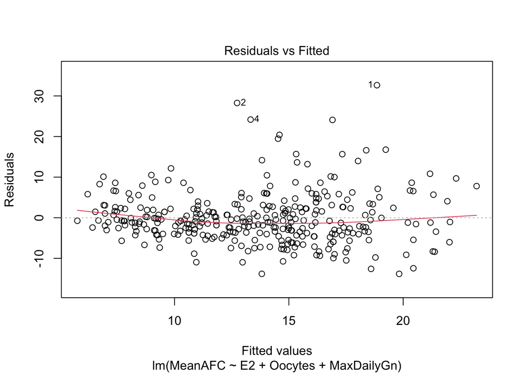

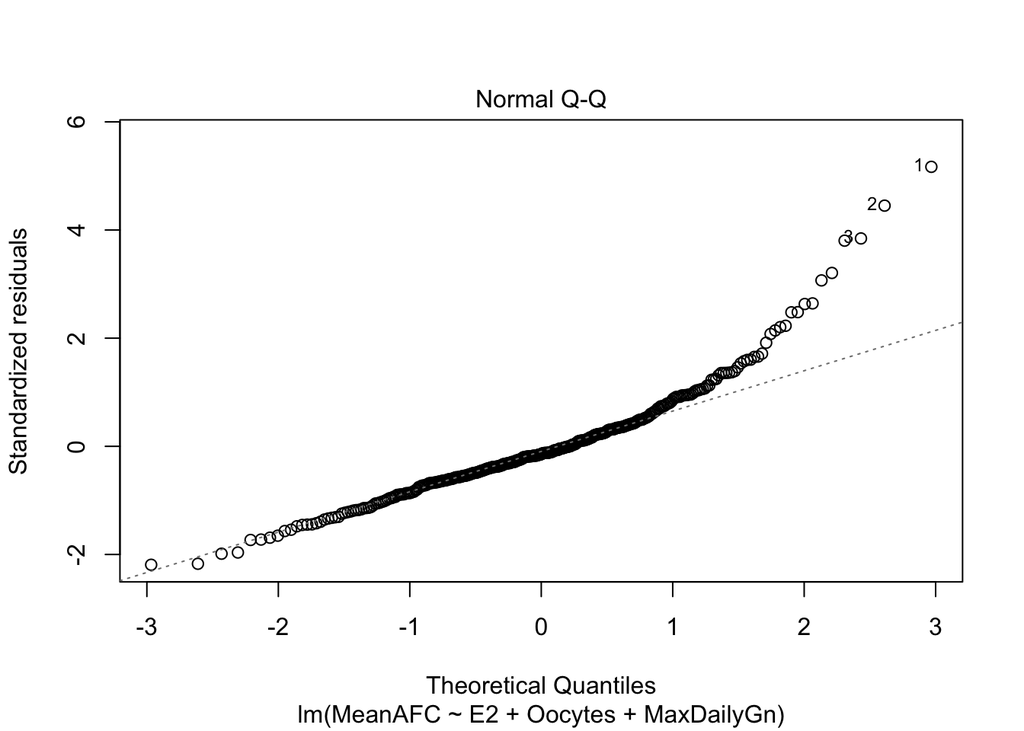

```r
plot(bsmod, 1:2)
```

I am not fully satisfied with the linear fit of this three-variable model. The t-test yields statistically significant associations for all three variables and the residual plot displays reasonable homoscedasticity. However, the Q-Q plot exhibits a significant right skew at the large residual values.

### Exercise 4.8

**A.** The CountyHealth dataset is used to predict the number of physicians in counties based on the number of hospitals. Use the first 35 counties in the CountyHealth dataset as a training sample to fit a model to predict TsqrtMDs based on Hospitals. Write down the equation of the least squares line.

```r
data("CountyHealth")
CountyHealth <- CountyHealth %>%
  mutate(TsqrtMDs = sqrt(MDs))
train <- CountyHealth[1:35,]
chmod1 <- lm(TsqrtMDs ~ Hospitals, train)
summary(chmod1)
```

```
##
## Call:
## lm(formula = TsqrtMDs ~ Hospitals, data = train)
##
## Residuals:
##     Min      1Q  Median      3Q     Max
## -18.582  -6.362  -2.918   8.277  23.170
##
## Coefficients:
##             Estimate Std. Error t value Pr(>|t|)
## (Intercept)  -3.1695     2.6915  -1.178    0.247
## Hospitals     6.7853     0.5284  12.841 2.19e-14 ***
## ---
## Signif. codes:  0 '***' 0.001 '**' 0.01 '*' 0.05 '.' 0.1 ' ' 1
##
## Residual standard error: 9.627 on 33 degrees of freedom
## Multiple R-squared:  0.8332, Adjusted R-squared:  0.8282
## F-statistic: 164.9 on 1 and 33 DF,  p-value: 2.194e-14
```

$\hat{TsqrtMDs}$ = 6.7853*Hospitals - 3.1695

**B.** Compute predictions for the holdout sample (last 18 cases in the original file) and find the cross-validation correlation.

```r
test = dplyr::anti_join(CountyHealth, train, by = 'County')
chmod2 <- lm(TsqrtMDs ~ Hospitals, test)
summary(chmod2)
```

```
##
## Call:
## lm(formula = TsqrtMDs ~ Hospitals, data = test)
##
## Residuals:
##      Min       1Q   Median       3Q      Max
## -10.5834  -4.2935   0.4812   3.1122  12.9001
##
## Coefficients:
##             Estimate Std. Error t value Pr(>|t|)
## (Intercept)  -2.3014     2.6449   -0.87    0.397
## Hospitals     7.1610     0.5682   12.60 1.01e-09 ***
## ---
## Signif. codes:  0 '***' 0.001 '**' 0.01 '*' 0.05 '.' 0.1 ' ' 1
##
## Residual standard error: 6.556 on 16 degrees of freedom
## Multiple R-squared:  0.9085, Adjusted R-squared:  0.9028
## F-statistic: 158.8 on 1 and 16 DF,  p-value: 1.008e-09
```

```r
pred = predict(chmod1, newdata = test, type = "response")
cor(test$TsqrtMDs, pred)
```

```
## [1] 0.9531439
```

**C.** Compute the shrinkage and comment on what it tells you about the effectiveness of this model.

```r
cor(test$TsqrtMDs, pred)^2
```

```
## [1] 0.9084832
```

```r
83.32-90.85
```

```
## [1] -7.53
```

The prediction R^2 is higher than the R^2 value on the training data, therefore making the shrinkage negative. This makes the model overly effective and suggests potential problems with either the data itself or the way in which we separated the training data from the test data.